# Relationship Between ICC and Percent Agreement

April 10, 2023

## Motivation

- The Diagnostic Assessment and Achievement of College Skills (DAACS; [www.DAACS.net](https://www.daacs.net)) is a suite of technological and social supports to optimize student learning. **DAACS provides personalized feedback** about students’ **strengths** and **weaknesses** in terms of key academic (mathematics, reading, & writing) and self-regulated learning skills, linking them to the resources to help them be successful students.
- For the writing assessment, were trying to establish inter-rater reliability in two ways:
  1. Human-to-human
  2. Human-to-machine
- Literature clearly suggests ICC is the appropriate measure, however most of that research is from the medical literature.
- Guidance on interpretation of ICC is not very clear.

## Guiding Research Questions

1. What is the relationship between intraclass correlation (ICC) and percent rater agreement (PRA)?
2. Are the published guidelines for interpreting ICC appropriate for all rating designs?

## Measuring Inter-rater Reliability

Percent Rater Agreement (PRA)

- Percentage of scoring events where raters’ scores agree.

Intraclass Correlation (ICC)

- ICC is a quantitative measurements are made on units that are organized into groups. It describes how strongly units in the same group resemble each other

Cohen’s Kappa

- Measure of agreement between two raters that takes into account agreement by chance.

Fleiss’ Kappa

- Extension of Cohen’s kappa for more than two raters. It also takes into account agreement by chance.

## Components of Measuring IRR

Models:

- **One-way random** effects: each subject is measured by a different set of k randomly selected raters.
- **Two-way random** effects: k raters are randomly selected, then, each subject is measured by the same set of k raters.
- **Two-way mixed** effects: k fixed raters are defined. Each subject is measured by the k raters.

Number of measurements:

- **Single measures**: even though more than one measure is taken in the experiment, reliability is applied to a context where a single measure of a single rater will be performed.
- **Average measures**: the reliability is applied to a context where measures of k raters will be averaged for each subject.

Consistency or absolute agreement:

- **Absolute agreement**: the agreement between two raters is of interest, including systematic errors of both raters and random residual errors.
- **Consistency**: in the context of repeated measurements by the same rater, systematic errors of the rater are canceled and only the random residual error is kept.

| IRR Statistic | Description | Formula |
| --- | --- | --- |
| Percent Agreement | One-way random effects; Absolute agreement | \(\frac{number\ of\ observations\ agreed\ upon}{total\ number\ of\ observations}\) |
| ICC(1,1) | One-way random effects; absolute agreement; single measurements | \(\frac{MS_R - MS_W}{MS_R + (k - 1)MS_W}\) |
| ICC(2,1) | Two-way random effects; absolute agreement; single measures | \(\frac{MS_R - MS_W}{MS_R + (k - 1)MS_E + \frac{k}{n}(MS_C - MS_E)}\) |
| ICC(3,1) | Two-way random mixed effects; consistency; single measures. | \(\frac{MS_R - MS_E}{MS_R + (k-1)MS_E}\) |
| ICC(1,*k*) | One-way random effects; absolute agreement; average measures. | \(\frac{MS_R - MS_W}{MS_R}\) |
| ICC(2,*k*) | Two-way random effects; absolute agreement; average measures. | \(\frac{MS_R - MS_E}{MS_R \| \frac{MS_C - MS_E}{n}}\) |
| ICC(3,*k*) | Two-way mixed effects; consistency; average measures. | \(\frac{MS_R - MS_E}{MS_R}\) |
| Cohen’s Kappa | Absolute agreement | \(\frac{P_o - P_e}{1 - P_e}\) |

*Note.* \(MS_R\) = mean square for rows; \(MS_W\) = mean square for residual sources of variance; \(MS_E\) = mean square error; \(MS_C\) = mean square for columns; \(P_o\) = observed agreement rates; \(P_e\) = expected agreement rates.

## Guidelines for Interpreting IRR

Altman (1990) (**Not specified**)

< 0.2 Poor

0.2 - 0.4 Fair

0.4 - 0.6 Moderate

0.6 - 0.8 Good

>0.8 Very good

Cicchetti & Sparrow (1981); Cicchetti (2001) (**ICC, Cohen Kappa**)

< 0.4 Poor

0.4 - 0.6 Fair

0.6 - 0.75 Good

>0.75 Excellent

Fleiss (1981, 1986); Brage et al. (1998); Martin et al. (1997); Svanholm et al. (1989) (**Cohen Kappa**)

< 0.4 Poor

0.4 - 0.75 Fair

>0.75 Excellent

Koo & Li (2016) (**ICC**)

< 0.5 Poor

0.5 - 0.75 Moderate

0.75 - 0.9 Good

>0.9 Excellent

Landis & Koch (1997); Zeger et al. (2010) (**Cohen Kappa**)

< 0.2 Slight

0.2 - 0.4 Fair

0.4 - 0.6 Moderate

0.6 - 0.8 Substantial

>0.8 Almost perfect

Portney & Watkins (2009) (**ICC**)

< 0.75 Poor to moderate

>0.75 Reasonable for clinical measurement

Shrout (1998) (**Not specified**)

< 0.1 Virtually none

0.1 - 0.4 Slight

0.4 - 0.6 Fair

0.6 - 0.8 Moderate

>0.8 Substantial

## Guidelines for Interpreting IRR

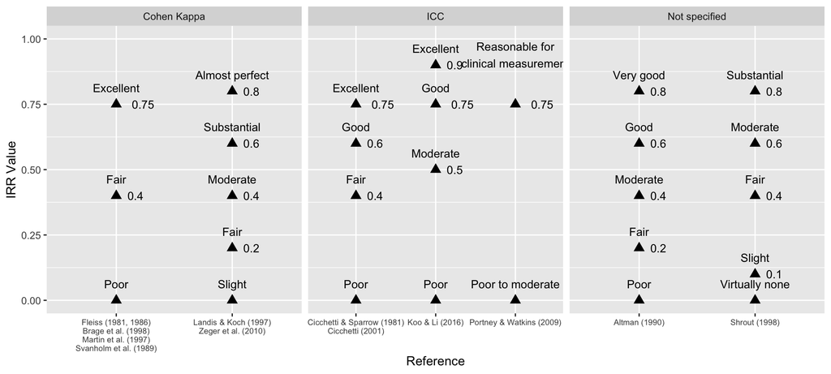

## Guidelines for Education

In education, ICC(1,1) is *often* the most appropriate intraclass correlation (ICC) metric to use given each subject is measured by two randomly selected raters (one-way), single measures are used, and absolute agreement is desired (Shrout & Fleiss, 1979).

Guidelines for interpreting ICC is largely found in the medical literature. When discussing to ICC(1,1), Koo and Li (2016) state that **“practically, this model is rarely used in clinical reliability analysis because majority of the reliability studies typically involve the same set of raters to measure all subjects”** (pp. 156-157).

The guidelines for interpreting ICC may not be appropriate for all forms of ICC. As will be shown, the magnitude of the ICC vary greatly for the same percent agreement.

## The IRRsim R Package

The `IRRsim` package provides functions to simulate various scoring designs.

```r
devtools::install_github('jbryer/IRRsim')
```

```r
library(IRRsim)
```

Key functions:

- `simulateRatingMatrix` - Simulate a single rating matrix.
- `simulateIRR` - Simulates many scoring matrices with varying percent rater agreements. S3 methods implemented for objects returned by `simulateIRR`:
  - `summary`
  - `plot`
  - `as.data.frame`
- `IRRsim_demo` - Run an interactive Shiny application.

## `simulateRatingMatrix`

Simulate a single rating matrix.

For each scoring event (i.e. row within a scoring matrix):

1. One of *k* raters is randomly selected.
2. A score, *y*, is randomly selected from the response distribution (uniform distribution by default)
3. A random number, *x*, between 0 and 1 is generated.
   - If *x* is less than the specified desired percent agreement, the remaining values in the row are set to *y*.
   - Otherwise, scores for the remaining raters are randomly selected from the response distribution.
4. Repeat steps 1 through 3 for the remaining scoring events.
5. If \(k_m < k\), then \(k - k_m\) scores per row are set to `NA` (missing).

## Simulating Scoring Matrices

```r
set.seed(2112)
test1 <- simulateRatingMatrix(
    nLevels = 3, k = 6, k_per_event = 6,
    agree = 0.6, nEvents = 10)
test1
```

```
##    aa ab ac ad ae af
## 1   1  1  1  1  1  1
## 2   2  2  2  2  2  2
## 3   1  1  1  1  1  1
## 4   1  1  1  2  1  1
## 5   2  1  2  1  3  1
## 6   2  2  2  2  2  2
## 7   2  2  2  2  2  2
## 8   2  2  1  1  1  2
## 9   2  2  2  2  2  2
## 10  3  1  3  2  3  2
```

```r
agreement(test1)
```

```
## [1] 0.6
```

```r
set.seed(2112)
test2 <- simulateRatingMatrix(
    nLevels = 3, k = 6, k_per_event = 2,
    agree = 0.6, nEvents = 10)
test2
```

```
##    aa ab ac ad ae af
## 1  NA  1 NA  1 NA NA
## 2  NA NA NA NA  2  2
## 3   1 NA NA NA  1 NA
## 4  NA NA  1 NA  1 NA
## 5  NA NA  2 NA NA  1
## 6   2 NA  2 NA NA NA
## 7  NA  2 NA  2 NA NA
## 8  NA NA  1 NA NA  2
## 9  NA NA NA  2  2 NA
## 10  3  1 NA NA NA NA
```

```r
agreement(test2)
```

```
## [1] 0.7
```

## `simulateIRR`

Simulates many scoring matrices with varying percent rater agreements. For each scoring matrix, IRR statistics are calculated. This functions returns an object of type `IRRsim` which has S3 methods defined for `plot`, `summary`, and `as.data.frame`.

For the remainder of the document, we wish to estimate ICC for 6, 9, and 12 raters under the conditions of 3, 5, and 9 scoring levels.

```r
tests.3levels <- simulateIRR(nRaters = c(6, 9, 12), nRatersPerEvent = 2, nLevels = 3)
tests.5levels <- simulateIRR(nRaters = c(6, 9, 12), nRatersPerEvent = 2, nLevels = 5)
tests.9levels <- simulateIRR(nRaters = c(6, 9, 12), nRatersPerEvent = 2, nLevels = 9)
```

Note that if the parameter `parallel = TRUE` is specified, the function will use multiple cores if available.

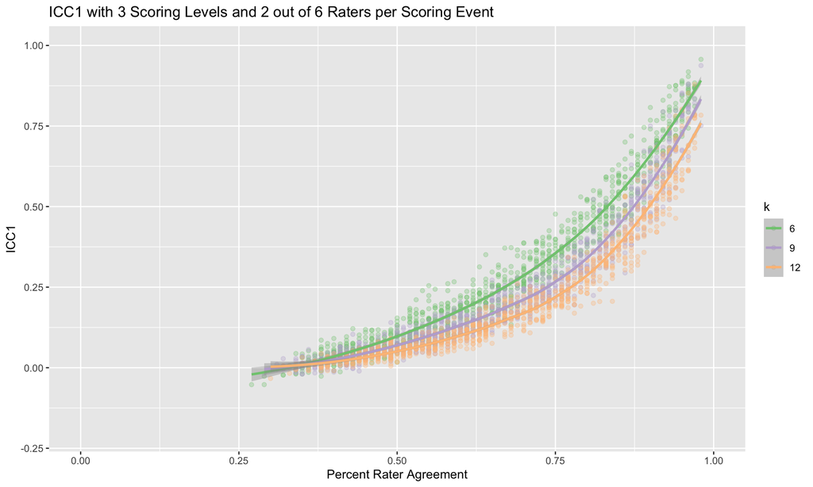

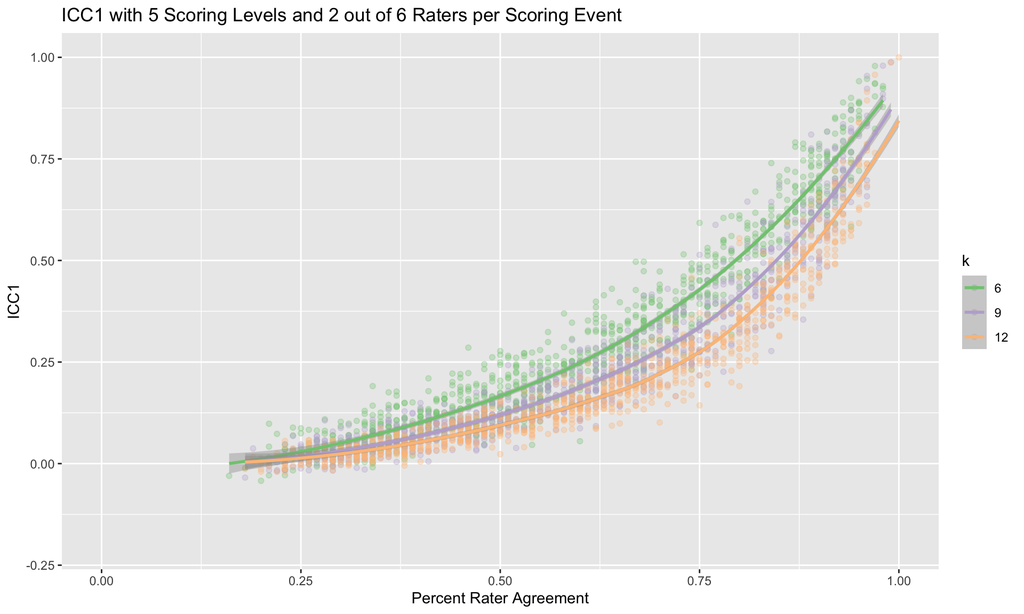

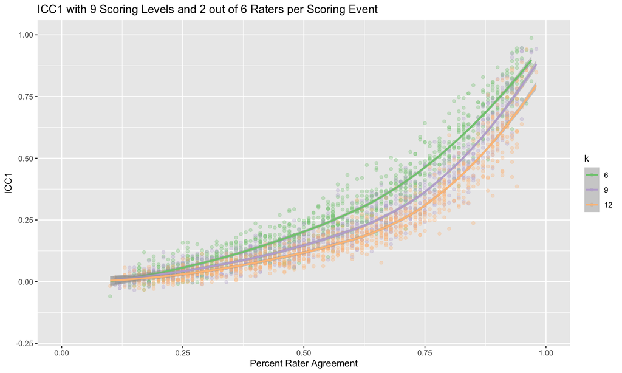

```r
tests.3levels.sum <- summary(tests.3levels, stat = 'ICC1', method = 'quadratic')
summary(tests.3levels.sum$model[[1]]) # k = 6 raters
```

```
##
## Call:
## lm(formula = as.formula(paste0(stat, " ~ I(agreement^2) + agreement")),
##     data = test)
##
## Residuals:
##       Min        1Q    Median        3Q       Max
## -0.159335 -0.031613 -0.000844  0.029938  0.150462
##
## Coefficients:
##                Estimate Std. Error t value Pr(>|t|)
## (Intercept)     0.26716    0.02291   11.66   <2e-16 ***
## I(agreement^2)  1.99424    0.05465   36.49   <2e-16 ***
## agreement      -1.36150    0.07270  -18.73   <2e-16 ***
## ---
## Signif. codes:  0 '***' 0.001 '**' 0.01 '*' 0.05 '.' 0.1 ' ' 1
##
## Residual standard error: 0.04885 on 897 degrees of freedom
## Multiple R-squared:  0.9589, Adjusted R-squared:  0.9588
## F-statistic: 1.047e+04 on 2 and 897 DF,  p-value: < 2.2e-16
```

**96% of the variance in ICC(1,1) is accounted for by percent agreement!**

## Simulating Different Response Distributions

```r
# Uniform response distribution
test1.3levels <- simulateIRR(nRaters = c(6, 9, 12), nRatersPerEvent = 2, nLevels = 3,
                             response.probs = c(.33, .33, .33))
# Lightly skewed response distribution
test4.3levels <- simulateIRR(nRaters = c(6, 9, 12), nRatersPerEvent = 2, nLevels = 3,
                             response.probs = c(.275, .275, .45))
# Moderately skewed response distributions
test2.3levels <- simulateIRR(nRaters = c(6, 9, 12), nRatersPerEvent = 2, nLevels = 3,
                             response.probs = c(.2, .2, .6))
# Highly skewed response distributions
test3.3levels <- simulateIRR(nRaters = c(6, 9, 12), nRatersPerEvent = 2, nLevels = 3,
                             response.probs = c(.1, .1, .8))
```

Uniform Distribution

```
## .
##         1         2         3
## 0.3331093 0.3342741 0.3326167
```

Lightly Skewed

```
## .
##         1         2         3
## 0.2749074 0.2748315 0.4502611
```

Moderately Skewed

```
## .
##         1         2         3
## 0.1997296 0.2014611 0.5988093
```

Highly Skewed

```
## .
##         1         2         3
## 0.1000667 0.1004574 0.7994759
```

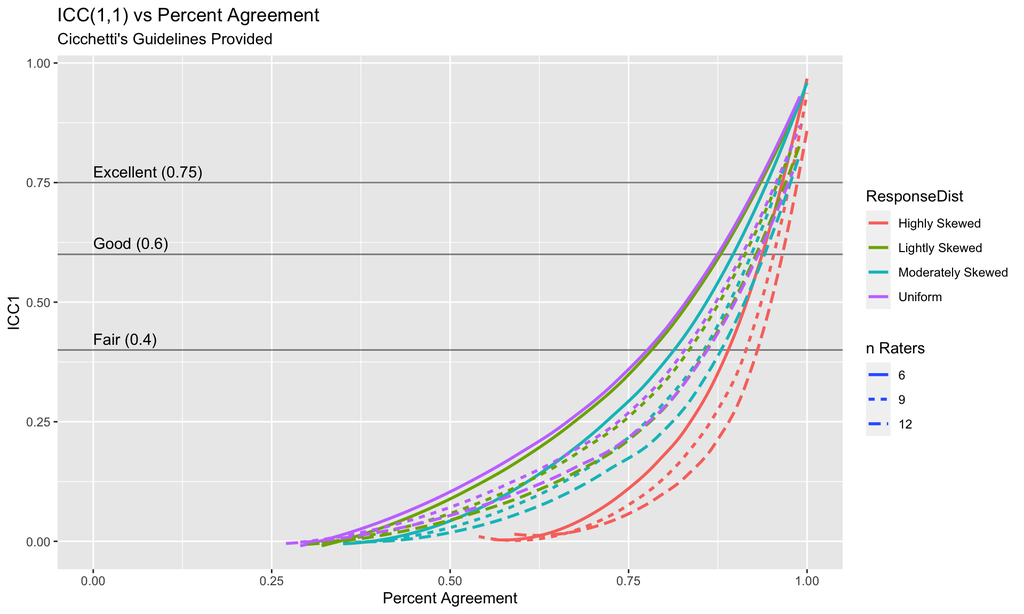

## Modeling ICC from Percent Agreement

For each scoring design (i.e. \(k\), \(k_m\), & number of scoring levels), the following model was estimated:

\[ICC = \beta_{PRA}^2 + \beta_{PRA} + B_0\]

For ICC(1,k), ICC(2,k), and ICC(3,k), the relationship is weaker as \(k_m\) approaches \(k\).

However, when \(k_m < \frac{k}{2}\), \(R^2 \ge 0.80\).

|  | Mean | Median | Minimum | Maximum |
| --- | --- | --- | --- | --- |
| ICC1 | 0.91 | 0.93 | 0.71 | 0.99 |
| ICC2 | 0.91 | 0.93 | 0.71 | 0.99 |
| ICC3 | 0.91 | 0.93 | 0.71 | 0.99 |
| ICC1k | 0.78 | 0.79 | 0.63 | 0.88 |
| ICC2k | 0.78 | 0.79 | 0.63 | 0.88 |
| ICC3k | 0.78 | 0.79 | 0.63 | 0.88 |

## Shiny Application

An interactive Shiny web application was developed to facilitate the simulation of scoring matrices for any particular scoring design.

[figure not shown]

```r
IRRsim_demo()
```

## Recommendations

- Researchers should **report their full scoring design** including \(k\), \(k_m\), and number of scoring levels.
- **Report/utilize percent agreement**. This metric is much more understandable.

## Thank You!

### Jason Bryer, Ph.D.

City University of New York  
jason@bryer.org

### Website: [irrsim.bryer.org](http://irrsim.bryer.org/)

### Source Code: github.com/jbryer/IRRsim

DAACS was developed under grant #P116F150077 from the U.S. Department of Education. However, the contents do not necessarily represent the policy of the U.S. Department of Education, and you should not assume endorsement by the Federal Government.